# Conditional Outputs with `blastula`

## Goals

The goal of this document is to demonstrate different conditional outcomes in rendering reports on Posit Connect:

- Using `blastula` to create a different customized emails that will replace the default email sent by Posit Connect
- Using `blastula` to suppress email output depending on condition
- Using `knitr::knit_exit()` to stop executing code and exit the report rendering on condition

## Setup

### Load required packages for summarizing data and creating emails

```r
library(tidyverse)
library(blastula)
library(glue)
```

## Generate Conditional Outcome

For demonstration, let’s define 4 possible outcomes:

- **case 1** - Send an email with a cat picture
- **case 2** - Send an email with a dog picture
- **case 3** - Do not send any emails but still render this notebook completely
- **case 4** - Send a “something went wrong” email and prematurely end notebook rendering

```r
# randomly select a case 1, 2, 3, or 4
case <- sample(1:4, 1)
```

For this rendering, it’s going to be:

### case 1!

## Render and attach the email (if appropriate)

With `blastula`, we first render the email, which is a separate Rmd file. Because it’s R Markdown, we can take advantage of markdown formatting and mix prose with code.

```r
if(case == 1){
  email <- blastula::render_connect_email("case1_email.Rmd")
  subject <- glue("🐈 Meow! Here's the cat of the day for {wday(today(), label = TRUE, abbr = FALSE)}")
}

if(case == 2){
  email <- blastula::render_connect_email("case2_email.Rmd")
  subject <- glue("🐕 Woof! It's {wday(today(), label = TRUE, abbr = FALSE)}, here's a pup!")

}

if(case == 4){
  email <- blastula::render_connect_email("case4_email.Rmd")
  subject <- glue("⚠️ There was an issue with the {wday(today(), label = TRUE, abbr = FALSE)} report")
}

if(case %in% c(1,2,4)){
  send_email <- TRUE
}else{send_email <- FALSE}
```

With the rendered email saved as the object `email`, we now attach it as the output of this report using `blastula::attach_connect_email()`.

```r
# only do this if `send_email` is TRUE
if(send_email == TRUE){
  blastula::attach_connect_email(email,
                                 subject = subject)
# otherwise don't send any emails
}else{
  blastula::suppress_scheduled_email()
}
```

## Create the escape hatch

If it’s case 4, we want to stop this report *right now*

```r
if(case == 4){knitr::knit_exit("👋")}
```

Are you still there? Phew, that means it wasn’t case 4 and we’re still going strong.

## Log what we did

We can have this report include the email output as part of its rendering. This is great to be able to see what email was generated during the rendering. Access historical renderings from the [Report History option in Connect](https://docs.posit.co/connect/user/report-history/).

Output the html of the rendered email by accessing the `html_html` attribute of your rendered email object. Set the code chunk option `results="asis"` to pass the html directly (R Markdown will not try to process it)

Here’s how it’s done:

```r
# give a nice timestamp
if(case == 3){glue(
    "### Report run {blastula::add_readable_time()}

     ### This report was processed for **Case** {case}

     ### No email was sent.")}else
       {
glue("### Report run {blastula::add_readable_time()}

     ### This report was processed for **Case** {case}

     ### Here is a preview of the email rendered with this report:

     ---")
     }
```

### Report run Thursday, October 19, 2023 at 10:29 AM (PDT)

### This report was processed for **Case** 1

### Here is a preview of the email rendered with this report:

```r
if(case %in% c(1,2)){
glue("**Subject: {subject}**")
email$html_html}
```

# Happy Thursday!

Here’s your cat of the day.

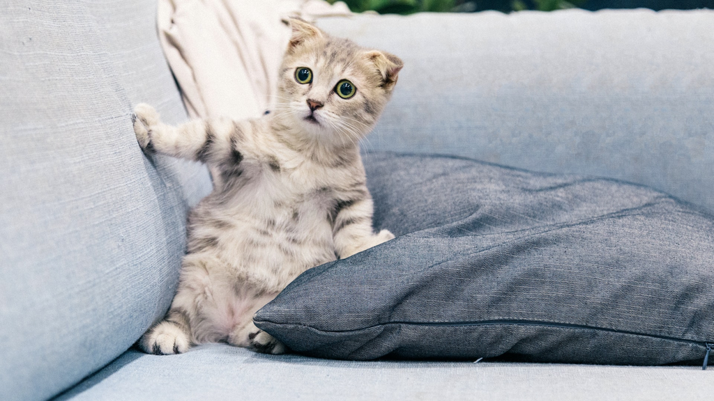

I hope you have a lovely day. You are funkadelic! Go get ’em, tiger!

This message was generated on Thursday, October 19, 2023 at 10:29 AM (PDT).

This Version: https://connect.example.com/content/1234/_rev5678  
Latest Version: https://connect.example.com/content/1234/

If you wish to stop receiving emails for this document, you may [unsubscribe here](https://connect.example.com/connect/#/apps/1234/subscriptions).

If HTML documents are attached, they may not render correctly when viewed in some email clients. For a better experience, download HTML documents to disk before opening in a web browser.